# Simulation study: CLT

Can LUO

# 1 Introduction

In probability theory, the central limit theorem (CLT) establishes that, in some situations, when independent random variables are added, their properly normalized sum tends toward a normal distribution (informally a “bell curve”) even if the original variables themselves are not normally distributed. The theorem is a key concept in probability theory because it implies that probabilistic and statistical methods that work for normal distributions can be applicable to many problems involving other types of distributions.

The central limit theorem is an important computational short-cut for generating and making inference from the sampling distribution of the mean. The central limit theorem short-cut relies on a number of conditions, specifically:

1.Independent observations

2.Identically distributed observations

3.Mean and variance exist

4.Sample size large enough for convergence

In this blog post, I’m going to compare the sampling distribution of the mean generated by simulation to the sampling distribution implied by the central limit theorem. I will compare the distributions graphically in QQ-plots.

This will be a 4 × 4 factorial experiment. The first factor will be the sample size, with N = 5, 10, 20, and 40. The second factor will be the degree of skewness in the underlying distribution. The underlying distribution will be the Skew-Normal distribution. The Skew-Normal distribution has three parameters: location, scale, and slant. When the slant parameter is 0, the distribution reverts to the normal distribution. As the slant parameter increases, the distribution becomes increasingly skewed. In this simulation, slant will be set to 0, 2, 10, 100. Set location and scale to 0 and 1, respectively, for all simulation settings.

# 2 CLT and simulation

```r
library(tidyverse)
```

The input settings are as below.

```r
settings<-expand.grid(N=c(5,10,20,40),slant=c(0,2,10,100))
settings
```

| N | slant |
| --- | --- |
| 5 | 0 |
| 10 | 0 |
| 20 | 0 |
| 40 | 0 |
| 5 | 2 |
| 10 | 2 |
| 20 | 2 |
| 40 | 2 |
| 5 | 10 |
| 10 | 10 |

[output cut: 6 more lines]

We can see how the skewed normal distribution looks like as below according to different slant of the input settings.

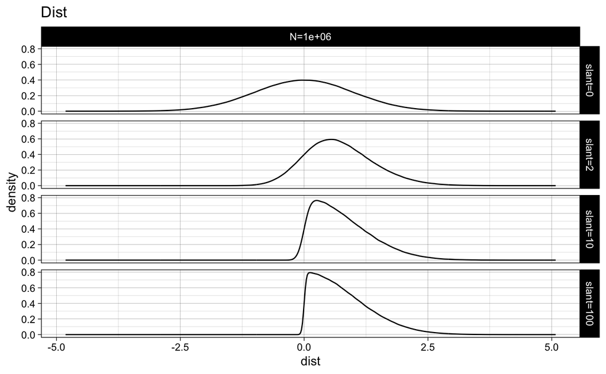

When the slant becomes larger, the distribution looks more skew.

Then I use simulation and CLT approach to esitimate the distribution. The outcomes are compared by QQ plot.

```r
output<-settings%>%
  split(seq(nrow(.))) %>%
  map(generate_data) %>%
  do.call(rbind,.)

output
```

|  | N | slant | N_f | slant_f | sample_dist_sim | sample_dist_clt |
| --- | --- | --- | --- | --- | --- | --- |
| 1.1 | 5 | 0 | N=5 | slant=0 | -1.7711210 | -1.3767333 |
| 1.2 | 5 | 0 | N=5 | slant=0 | -1.5038660 | -1.3524893 |
| 1.3 | 5 | 0 | N=5 | slant=0 | -1.4212711 | -1.3242734 |
| 1.4 | 5 | 0 | N=5 | slant=0 | -1.4023556 | -1.3214114 |
| 1.5 | 5 | 0 | N=5 | slant=0 | -1.3784923 | -1.2926453 |
| 1.6 | 5 | 0 | N=5 | slant=0 | -1.3700224 | -1.2911714 |
| 1.7 | 5 | 0 | N=5 | slant=0 | -1.2993753 | -1.2839084 |
| 1.8 | 5 | 0 | N=5 | slant=0 | -1.2899598 | -1.2809820 |
| 1.9 | 5 | 0 | N=5 | slant=0 | -1.2889109 | -1.2754829 |
| 1.10 | 5 | 0 | N=5 | slant=0 | -1.2861071 | -1.2679620 |

[output cut: 990 more lines]

```r
graph2<-ggplot(output,aes(x = sample_dist_clt,
           y = sample_dist_sim)) +
  geom_point(alpha = 0.8,
             size = 0.4) +geom_abline(slope = 1,size=.1,col='purple')+
  theme_linedraw() +
  labs(title = "QQ plot"
      ) +
facet_grid(rows=vars(slant_f),cols=vars(N_f))
```

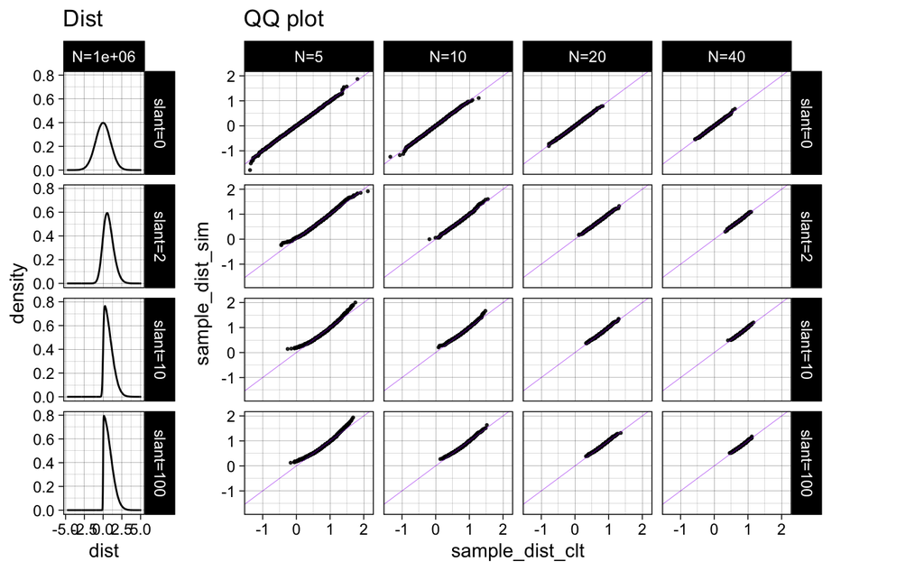

For the figures,we can see that outcome of CLT estimation comply with outcome of simulation approach when estimating a skew normal distribution.

When the sample size N becomes larger, CLT estimation fits better with simulation outcome.

When the slant becomes greater, CLT estimation is less accurate than when slant is smaller.

# 3 Conclusion

CLT estimation has very close result compared with simulation approach.So the central limit theorem is a good computational short-cut for generating and making inference from the sampling distribution of the mean.